# 1. Lab 1: Euler Beam

### 2.2.13. Test Pretrained Model

- [branch_net_u_pretrained](https://www.dropbox.com/scl/fi/q6enpoiqct5uw51ruapcr/tp_branch_net_u.pt?rlkey=g8kzo0xwj8aehohxvosbcwzb3&st=w9mjml35&dl=1)
- [branch_net_v_pretrained](https://www.dropbox.com/scl/fi/6px9i5b0jwb8wrj8w1623/tp_branch_net_v.pt?rlkey=yrboe3huq8btmsqtb2690j753&st=zld9mm9t&dl=1)
- [trunk_net_u_pretrained](https://www.dropbox.com/scl/fi/n8c0dwjm5w7xrv9tbk1vx/tp_trunk_net_u.pt?rlkey=wicl535mheqir3853zed8nihd&st=uynx1ua2&dl=1)
- [trunk_net_v_pretrained](https://www.dropbox.com/scl/fi/f46phzvqe05ei6bf9fos5/tp_trunk_net_v.pt?rlkey=ccsndzmwvjsou5m8wg81z9up7&st=99db5kto&dl=1)

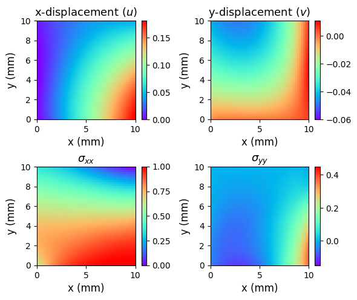

```python
branch_u_trained = torch.load('/content/drive/MyDrive/tutorials/기계인공지능연구회/본부학술대회_241106/DeepONet/weight/thin_plate/tp_branch_net_u.pt')
branch_v_trained = torch.load('/content/drive/MyDrive/tutorials/기계인공지능연구회/본부학술대회_241106/DeepONet/weight/thin_plate/tp_branch_net_v.pt')
trunk_u_trained = torch.load('/content/drive/MyDrive/tutorials/기계인공지능연구회/본부학술대회_241106/DeepONet/weight/thin_plate/tp_trunk_net_u.pt')
trunk_v_trained = torch.load('/content/drive/MyDrive/tutorials/기계인공지능연구회/본부학술대회_241106/DeepONet/weight/thin_plate/tp_trunk_net_v.pt')
test_u, test_v, test_sig_x, test_sig_y = PLOT(branch_u_trained, branch_v_trained, trunk_u_trained, trunk_v_trained)
```

- [Plate Data](https://www.dropbox.com/scl/fi/i568435e71d6tni220h30/Plate_data.npy?rlkey=96v37iges457uqezd7rp4mvw7&st=4vt10u0w&dl=1)

```python
Plate_data = np.load('/content/drive/MyDrive/tutorials/기계인공지능연구회/본부학술대회_241106/DeepONet/data/thin_plate/Plate_data.npy')
loc = Plate_data[:, 0:2]
u = Plate_data[:, 2:3]
v = Plate_data[:, 3:4]
stress = Plate_data[:, 4:6]
```

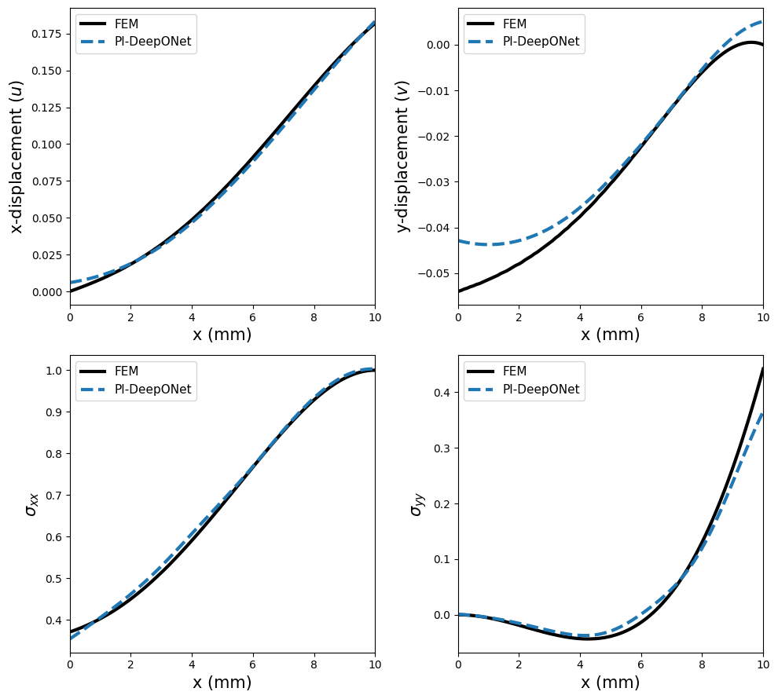

```python
def RESULT(model_test, con_test, XY_test):

    pde_u, pde_v = PIDeepOnet(model_test, con_test, XY_test)
    pde_disp = np.hstack([pde_u.cpu().detach().numpy(), pde_v.cpu().detach().numpy()])
    sig_x, sig_y = check_stress(model_test, XY_test, con_test)
    pde_sig = np.hstack([sig_x.cpu().detach().numpy(), sig_y.cpu().detach().numpy()])
    return pde_disp, pde_sig

diag_ = [i for i in range(u.shape[0]) if loc[i, 0] + loc[i, 1] == 10]
diag_x = np.linspace(0, 10, 101).reshape(-1, 1)
diag_y = -diag_x + 10
diag = np.concatenate((diag_x, diag_y), 1)
XY_test = diag
con_test = np.vstack([P_test] * XY_test.shape[0])

con_test, XY_test = requires_grad(con_test), requires_grad(XY_test)

model_test = [branch_u_trained, branch_v_trained, trunk_u_trained, trunk_v_trained]

results = {
    "FEM": [u[diag_], v[diag_], stress[diag_, 0], stress[diag_, 1]],
    "PI-DeepONet": RESULT(model_test, con_test, XY_test),
}

for key in ["PI-DeepONet"]:
    disp, sig = results[key]
    results[key] = [disp[:, 0], disp[:, 1], sig[:, 0], sig[:, 1]]

titles = ['x-displacement ($u$)', 'y-displacement ($v$)', '$\sigma_{xx}$', '$\sigma_{yy}$']
line_styles = {'FEM': 'k', 'PI-DeepONet': '--'}

plt.figure(figsize=(10, 9))

for idx, title in enumerate(titles):
    plt.subplot(2, 2, idx + 1)
    for label, result in results.items():
        plt.plot(diag[:, 0], result[idx], line_styles[label], linewidth=3, label=label)
    plt.xlabel('x (mm)', fontsize=15)
    plt.ylabel(title, fontsize=15)
    plt.xlim((0, 10))
    plt.legend(fontsize=11)

plt.tight_layout()
plt.show()
```

# 3. Lab 3: Flow Around a Cylinder

## 3.1. Problem Setup

- We will solve the Naiver-Stokes equation with varying viscosity term with PI-DeepONet
- Data and Physics-informed (PDE and BC)

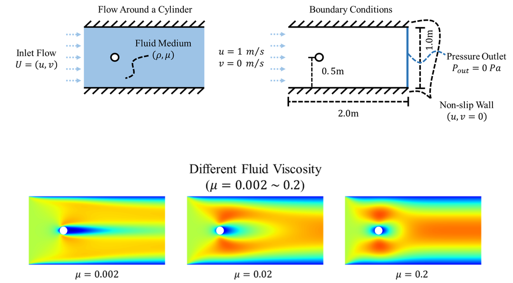

- Problem properties

- 2D Navier-Stokes Equations & boundary conditions (for steady state)

$$ \begin{align*} \rho \left(u{\partial u \over \partial x} + v{\partial u \over \partial y} + {1 \over \rho}{\partial p \over \partial x}\right) - \mu \ \left({\partial^2 u \over {\partial x^2}} + {\partial^2 u \over {\partial y^2}}\right) &= 0\\\\ \rho \left(u{\partial v \over \partial x} + v{\partial v \over \partial y} + {1 \over \rho}{\partial p \over \partial y}\right) - \mu \ \left({\partial^2 v \over {\partial x^2}} + {\partial^2 v \over {\partial y^2}}\right) &= 0\\\\ {\partial u \over \partial x} + {\partial v \over \partial y} &= 0 \end{align*} $$

- Two Dirichlet boundary conditions on the plate boundary (no-slip condition)

$$u(x,y) = 0, \quad v(x,y) = 0 \qquad \text{at} \quad y = \frac{D}{2} \ \; \text{or} \; -\frac{D}{2}$$

- Two Dirichlet boundary conditions at the outlet boundary

- Two Dirichlet boundary conditions at the cylinder boundary

$$u(\text{cylinder}) = 0, \quad v(\text{cylinder}) = 0$$

- Make a neural network and loss functions like below :

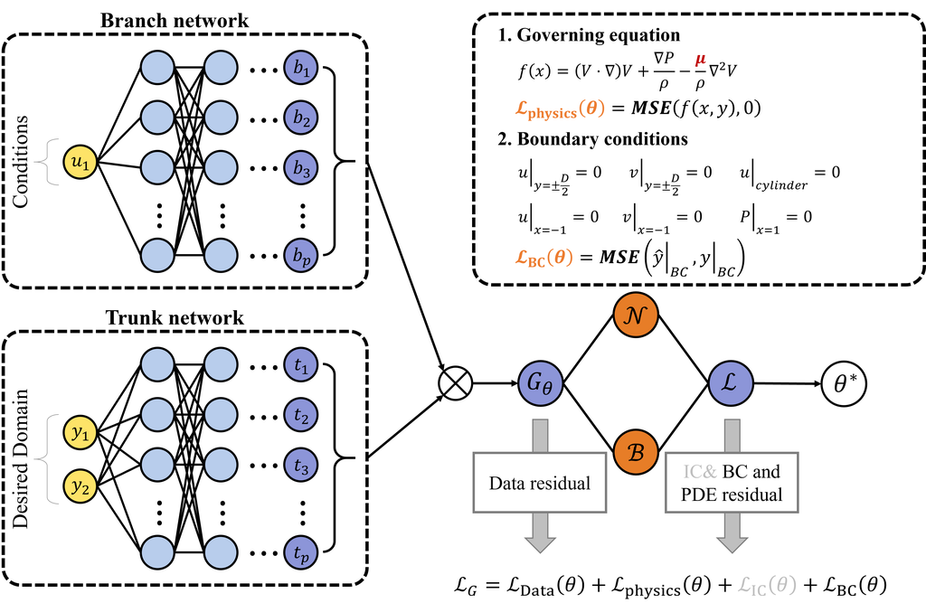

```python
from google.colab import drive
drive.mount('/content/drive')
```

## 3.2. Solve the Navier-Stokes Equations with PI-DeepONet

### 3.2.1.Load Library

```python
import numpy as np
import matplotlib.pyplot as plt
import random
import torch
import torch.nn as nn
import torch.optim as optim
from torch.utils import data

%matplotlib inline

import os
import warnings
warnings.filterwarnings("ignore")
```

### 3.2.2. CUDA

```python
device = torch.device('cuda:0' if torch.cuda.is_available() else 'cpu')
print(device)
```

```
cuda:0
```

### 3.2.3. Random Seed

```python
def random_seed(seed = 2021):
    random.seed(seed)
    np.random.seed(seed)
    torch.manual_seed(seed)
    torch.cuda.manual_seed_all(seed)
    torch.backends.cudnn.deterministic = True
    torch.backends.cudnn.benchmark = False
```

### 3.2.4. Define Conditions and Load Data

```python
vis_list = np.array([0.002, 0.004, 0.006, 0.008, 0.01, 0.02, 0.04, 0.06, 0.08, 0.1, 0.2]).reshape(-1, 1) # 11
vis_train = np.array([0.002, 0.004, 0.008, 0.01, 0.02, 0.06, 0.08, 0.1, 0.2]).reshape(-1, 1) # 9
vis_test = np.array([0.006, 0.04]).reshape(-1, 1) # 2


print("Number of train condition: {}".format(len(vis_train)))
print("Number of test condition:  {}".format(len(vis_test)))
```

```
Number of train condition: 9
Number of test condition:  2
```

- [train_xy_domain](https://www.dropbox.com/scl/fi/j8eglfmpa70n6c8qpepc1/viscosity_train_xy_domain.npy?rlkey=vvyda3ifg3r1svedztdyjcyhc&st=itlfievu&dl=1)
- [train_gt_domain](https://www.dropbox.com/scl/fi/exuohui5v2aegxr28d0s5/viscosity_train_gt_domain.npy?rlkey=nmmtku3putcxzfztt0wtbh1dx&st=1ku80lo3&dl=1)
- [test_xy_domain](https://www.dropbox.com/scl/fi/33dxnjg8tjfbw1xkw3wsv/viscosity_test_xy_domain.npy?rlkey=yjeju6ahk8ar3ttqg6wrt3eit&st=dnkpp6up&dl=1)
- [test_gt_domain](https://www.dropbox.com/scl/fi/aafhji51uampa74eo89a7/viscosity_test_gt_domain.npy?rlkey=8hsj1ui8t1pc3c3jj4m296x4t&st=w7iejhkp&dl=1)

```python
train_xy_domain = np.load('/content/drive/MyDrive/tutorials/기계인공지능연구회/본부학술대회_241106/DeepONet/data/viscosity/viscosity_train_xy_domain.npy')
train_gt_domain = np.load('/content/drive/MyDrive/tutorials/기계인공지능연구회/본부학술대회_241106/DeepONet/data/viscosity/viscosity_train_gt_domain.npy')
test_xy_domain = np.load('/content/drive/MyDrive/tutorials/기계인공지능연구회/본부학술대회_241106/DeepONet/data/viscosity/viscosity_test_xy_domain.npy')
test_gt_domain = np.load('/content/drive/MyDrive/tutorials/기계인공지능연구회/본부학술대회_241106/DeepONet/data/viscosity/viscosity_test_gt_domain.npy')
```

```python
print("train XY shape: {}".format(train_xy_domain.shape))
print("train gt shape: {}".format(train_gt_domain.shape))
print("test XY shape:  {}".format(test_xy_domain.shape))
print("test gt shape:  {}".format(test_gt_domain.shape))
```

```
train XY shape: (9, 19692, 2)
train gt shape: (9, 19692, 3)
test XY shape:  (2, 19692, 2)
test gt shape:  (2, 19692, 3)
```

### 3.2.5. Generate collocation points

#### Domain

```python
domain_points = train_xy_domain[0]
```

#### Boundary Condition

```python
bc_top_x = np.linspace(-0.5, 1.5, 200).reshape(-1, 1)
bc_top_y = 0.5 * np.ones_like(bc_top_x).reshape(-1, 1)

bc_bottom_x = np.linspace(-0.5, 1.5, 200).reshape(-1, 1)
bc_bottom_y = -0.5 * np.ones_like(bc_bottom_x).reshape(-1, 1)

bc_inlet_y = np.linspace(-0.5, 0.5, 100).reshape(-1, 1)
bc_inlet_x = -0.5 * np.ones_like(bc_inlet_y).reshape(-1, 1)

bc_outlet_y = np.linspace(-0.5, 0.5, 100).reshape(-1, 1)
bc_outlet_x = 1.5 * np.ones_like(bc_outlet_y).reshape(-1, 1)

radius = 0.05
theta = np.linspace(0, 2 * np.pi, 200)
bc_cylinder_x = (0 + radius * np.cos(theta)).reshape(-1, 1)
bc_cylinder_y = (0 + radius * np.sin(theta)).reshape(-1, 1)

bc_top_points = np.hstack((bc_top_x, bc_top_y))
bc_bottom_points = np.hstack((bc_bottom_x, bc_bottom_y))
bc_inlet_points = np.hstack((bc_inlet_x, bc_inlet_y))
bc_outlet_points = np.hstack((bc_outlet_x, bc_outlet_y))
bc_cylinder_points = np.hstack((bc_cylinder_x, bc_cylinder_y))

bc_wall_points = np.concatenate((bc_top_points, bc_bottom_points, bc_cylinder_points), 0)
```

#### PLOT

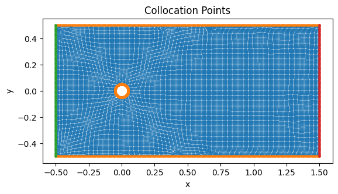

```python
plt.scatter(domain_points[:, 0], domain_points[:, 1], s = 1)
plt.scatter(bc_wall_points[:, 0], bc_wall_points[:, 1], s = 5)
plt.scatter(bc_inlet_points[:, 0], bc_inlet_points[:, 1], s = 5)
plt.scatter(bc_outlet_points[:, 0], bc_outlet_points[:, 1], s = 5)

plt.title('Collocation Points')
plt.axis('scaled')
plt.xlabel('x')
plt.ylabel('y')
plt.show()
```

### 3.2.6. Generate Dataset

- Generate a dataset by stacking data for all conditions and collocation points like below:

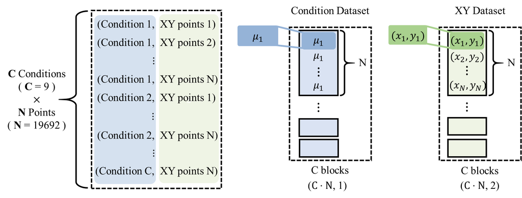

Domain

```python
# Domain dataset
num_domain = domain_points.shape[0]      # (19692, _)
num_condition = vis_train.shape[0]  #(9, _)

condition_list = []
XY_domain_list = []
gt_list = []

for i in range(num_condition):
    con = vis_train[i]
    conditions = np.vstack([con] * num_domain)
    domains = domain_points
    gts = train_gt_domain[i]

    condition_list.append(conditions)
    XY_domain_list.append(domains)
    gt_list.append(gts)

conditions_domain = np.vstack(condition_list)
XYs_domain = np.vstack(XY_domain_list)
gts_domain = np.vstack(gt_list)

print('Condtions Domain: {}'.format(conditions_domain.shape))
print('XYs Domain:       {}'.format(XYs_domain.shape))
print('GTs Domain:       {}'.format(gts_domain.shape))
```

```
Condtions Domain: (177228, 1)
XYs Domain:       (177228, 2)
GTs Domain:       (177228, 3)
```

#### BC Inlet

```python
num_BC = bc_inlet_points.shape[0]    # (100,_)
num_condition = vis_train.shape[0]  # (9,_)

condition_list = []
bc_list = []

for i in range(num_condition):
    con = vis_train[i]
    conditions = np.vstack([con] * num_BC)
    XYs_bc_inlet = bc_inlet_points

    condition_list.append(conditions)
    bc_list.append(XYs_bc_inlet)

conditions_bc_inlet = np.vstack(condition_list)
XYs_bc_inlet = np.vstack(bc_list)

print('Condtions BC: {}'.format(conditions_bc_inlet.shape))
print('XYs BC:       {}'.format(XYs_bc_inlet.shape))
```

```
Condtions BC: (900, 1)
XYs BC:       (900, 2)
```

#### BC Wall

```python
num_BC = bc_wall_points.shape[0]    # (200,_)
num_condition = vis_train.shape[0]  # (9,_)

condition_list = []
bc_list = []

for i in range(num_condition):
    con = vis_train[i]
    conditions = np.vstack([con] * num_BC)
    XYs_bc_wall = bc_wall_points

    condition_list.append(conditions)
    bc_list.append(XYs_bc_wall)

conditions_bc_wall = np.vstack(condition_list)
XYs_bc_wall = np.vstack(bc_list)

print('Condtions BC: {}'.format(conditions_bc_wall.shape))
print('XYs BC:       {}'.format(XYs_bc_wall.shape))
```

```
Condtions BC: (5400, 1)
XYs BC:       (5400, 2)
```

#### BC Outlet

```python
num_BC = bc_outlet_points.shape[0]    # (250,_)
num_condition = vis_train.shape[0]  # (10,_)

condition_list = []
bc_list = []

for i in range(num_condition):
    con = vis_train[i]
    conditions = np.vstack([con] * num_BC)
    XYs_bc_outlet = bc_outlet_points

    condition_list.append(conditions)
    bc_list.append(XYs_bc_outlet)

conditions_bc_outlet = np.vstack(condition_list)
XYs_bc_outlet = np.vstack(bc_list)

print('Condtions BC: {}'.format(conditions_bc_outlet.shape))
print('XYs BC:       {}'.format(XYs_bc_outlet.shape))
```

```
Condtions BC: (900, 1)
XYs BC:       (900, 2)
```

### 3.2.7. Data Generator

```python
# Data generator
class DataGenerator(data.Dataset):
    def __init__(self, c, XY, gt, batch_size=64, rng_seed=1234):
        'Initialization'
        self.c = torch.tensor(c, dtype = torch.float32)
        self.XY = torch.tensor(XY, dtype = torch.float32)
        self.gt = torch.tensor(gt, dtype = torch.float32)
        self.N = c.shape[0]
        self.batch_size = batch_size
        self.seed = rng_seed

    def __len__(self):
        return (self.N // self.batch_size) + 1

    def __getitem__(self, index):
        c, XY, gt = self.__data_generation(index)
        return c, XY, gt

    def __data_generation(self, index):
        torch.manual_seed(self.seed + index)

        idx = torch.randperm(self.N)[:self.batch_size]

        c = self.c[idx, :]
        XY = self.XY[idx, :]
        gt = self.gt[idx,:]

        return c, XY, gt


# BC generator
class BCGenerator(data.Dataset):
    def __init__(self, c, XY, batch_size=64, rng_seed=1234):
        'Initialization'
        self.c = torch.tensor(c, dtype = torch.float32)
        self.XY = torch.tensor(XY, dtype = torch.float32)
        self.N = c.shape[0]
        self.batch_size = batch_size
        self.seed = rng_seed

    def __len__(self):
        return (self.N // self.batch_size) + 1

    def __getitem__(self, index):
        c, XY= self.__data_generation(index)
        return c, XY

    def __data_generation(self, index):
        torch.manual_seed(self.seed + index)

        idx = torch.randperm(self.N)[:self.batch_size]

        c = self.c[idx, :]
        XY = self.XY[idx, :]

        return c, XY
```

```python
batch_size = 5000
train_domain = DataGenerator(conditions_domain, XYs_domain, gts_domain, batch_size)
train_inlet = BCGenerator(conditions_bc_inlet, XYs_bc_inlet, batch_size)
train_wall = BCGenerator(conditions_bc_wall, XYs_bc_wall, batch_size)
train_outlet = BCGenerator(conditions_bc_outlet, XYs_bc_outlet, batch_size)
```

### 3.2.8. Define Networks and Hyper-parameter

```python
class MLP(nn.Module):
    def __init__(self, input_dim):
        super().__init__()

        self.linears = nn.Sequential(
            nn.Linear(input_dim, 100),
            nn.Tanh(),
            nn.Linear(100, 100),
            nn.Tanh(),
            nn.Linear(100, 100),
            nn.Tanh(),
            nn.Linear(100, 100),
            nn.Tanh(),
            nn.Linear(100, 100),
            nn.Tanh(),
            nn.Linear(100, 100),
            nn.Tanh(),
            nn.Linear(100, 100)
        )

        self.init_weights()

    def init_weights(self):
        for m in self.modules():
            if isinstance(m, nn.Linear):
                nn.init.xavier_uniform_(m.weight)
                if m.bias is not None:
                    nn.init.zeros_(m.bias)

    def forward(self, x):
        a = x.float()
        return self.linears(a)
```

```python
random_seed()
# Initialize model
dim_vis = 1

branch_net_u = MLP(input_dim = dim_vis).to(device)
branch_net_v = MLP(input_dim = dim_vis).to(device)
branch_net_p = MLP(input_dim = dim_vis).to(device)
trunk_net_u = MLP(input_dim = 2).to(device)
trunk_net_v = MLP(input_dim = 2).to(device)
trunk_net_p = MLP(input_dim = 2).to(device)

optimizer = optim.Adam(
    list(branch_net_u.parameters()) + list(branch_net_v.parameters()) + list(branch_net_p.parameters()) +
    list(trunk_net_u.parameters()) + list(trunk_net_v.parameters()) + list(trunk_net_p.parameters()), lr=5e-4)
Loss_func = nn.MSELoss(reduction='mean')
```

### 3.2.9. Define Utility Function

```python
def PIDeepOnet(model, con_, XY_):
    '''
    model = [branch_net_u, branch_net_v,branch_net_p, trunk_net_u, trunk_net_v, trunk_net_p]
    '''

    branch_net_u = model[0]
    branch_net_v = model[1]
    branch_net_p = model[2]
    trunk_net_u = model[3]
    trunk_net_v = model[4]
    trunk_net_p = model[5]

    B1 = branch_net_u(con_)
    B2 = branch_net_v(con_)
    B3 = branch_net_p(con_)

    T1 = trunk_net_u(XY_)
    T2 = trunk_net_v(XY_)
    T3 = trunk_net_p(XY_)

    u = torch.sum(B1 * T1, dim=1).unsqueeze(1)
    v = torch.sum(B2 * T2, dim=1).unsqueeze(1)
    p = torch.sum(B3 * T3, dim=1).unsqueeze(1)

    return u, v, p

def derivative(y, t) :
    df = torch.autograd.grad(y, t, create_graph = True, retain_graph = True, grad_outputs = torch.ones(y.size()).to(device))[0]
    df_x = df[:, 0:1]
    df_y = df[:, 1:2]
    return df_x, df_y

def requires_grad(x):
    return torch.tensor(x, requires_grad = True).to(device)
```

```python
'PLOT'
from scipy.interpolate import griddata
import scipy.interpolate
import matplotlib.patches as patches
from IPython.display import clear_output

def PLOT(branch_net_u, branch_net_v, branch_net_p, trunk_net_u, trunk_net_v, trunk_net_p):
    branch_net_u.eval()
    branch_net_v.eval()
    branch_net_p.eval()
    trunk_net_u.eval()
    trunk_net_v.eval()
    trunk_net_p.eval()

    def interpolate_output(x, y, us,extent):
        "Interpolates irregular points onto a mesh"

        # define mesh to interpolate onto
        xyi = np.meshgrid(
        np.linspace(extent[0], extent[1], 100),
        np.linspace(extent[2], extent[3], 100),
            indexing="ij"
        )

        # linearly interpolate points onto mesh
        us = [scipy.interpolate.griddata(
            (x, y), u, tuple(xyi)
            )
            for u in us]

        return us

    with torch.no_grad():
        count = 0
        plt.figure(figsize=(14, 4))

        for i, gt in enumerate(gts):
            if i != 2 and i != 6:
                continue

            XY = XY_[i]

            x = XY[:,0]
            y = XY[:,1]
            u = gt[:,0]
            v = gt[:,1]
            # p = gt[:,2]
            gt_vel = np.sqrt(u**2 + v**2)

            num_col = len(gt)
            c_tmp = np.full((num_col, 1), vis_list[i])
            c_test = torch.tensor(c_tmp).to(device)
            XY_test = torch.tensor(XY).to(device)

            B_u = branch_net_u(c_test)
            B_v = branch_net_v(c_test)
            T_u = trunk_net_u(XY_test)
            T_v = trunk_net_v(XY_test)

            u_pred = torch.sum(B_u * T_u, dim=1)
            v_pred = torch.sum(B_v * T_v, dim=1)
            vel_pred = np.sqrt(u_pred.detach().cpu().numpy()**2 + v_pred.detach().cpu().numpy()**2)

            gt_inter, vel_inter, e_inter = interpolate_output(x, y,
                                                             [gt_vel, vel_pred, np.abs(gt_vel - vel_pred)],
                                                             [-0.5, 1.5, -0.5, 0.5])

            plt.subplot(2, 3, (count * 3) +1)
            if count == 0:
                plt.title('Ground Truth', fontsize=15)
            plt.imshow(gt_inter.T, origin = 'lower', extent=[-0.5, 1.5, -0.5, 0.5], vmin = np.min(gt_vel), vmax = np.max(gt_vel), cmap = 'jet')
            shp = patches.Circle((0, 0), radius=0.04, color='white')
            plt.gca().add_patch(shp)
            plt.colorbar()
            plt.axis('scaled')
            plt.ylabel('Vis: {}'.format(vis_list[i][0]), fontsize=13)

            plt.subplot(2, 3, (count * 3) + 2)
            if count == 0:
                plt.title('Prediction', fontsize=15)
            plt.imshow(vel_inter.T, origin = 'lower', extent = [-0.5, 1.5, -0.5, 0.5], vmin = np.min(gt_vel), vmax = np.max(gt_vel), cmap = 'jet')
            shp = patches.Circle((0, 0), radius=0.04, color='white')
            plt.gca().add_patch(shp)
            plt.colorbar()
            plt.axis('scaled')

            plt.subplot(2, 3, (count * 3) + 3)
            if count == 0:
                plt.title('Error', fontsize=15)
            plt.imshow(e_inter.T, origin = 'lower', extent = [-0.5, 1.5, -0.5, 0.5], vmin = 0, vmax = 0.3, cmap = 'jet')
            shp = patches.Circle((0, 0), radius = 0.04, color = 'white')
            plt.gca().add_patch(shp)
            plt.colorbar()
            plt.axis('scaled')

            count += 1
        plt.tight_layout()
        plt.show()
        clear_output(wait=True)

XY_ = np.concatenate((train_xy_domain[0:2], test_xy_domain[0:1], train_xy_domain[2:5], test_xy_domain[1:2], train_xy_domain[5:]), 0)
gts = np.concatenate((train_gt_domain[0:2], test_gt_domain[0:1], train_gt_domain[2:5], test_gt_domain[1:2], train_gt_domain[5:]), 0)
```

### 3.2.10. Define PDE with Boundary Conditions

- 2D Navier-Stokes Equations & boundary conditions (for steady state)

$$ \begin{align*} \rho \left(u{\partial u \over \partial x} + v{\partial u \over \partial y} + {1 \over \rho}{\partial p \over \partial x}\right) - \mu \ \left({\partial^2 u \over {\partial x^2}} + {\partial^2 u \over {\partial y^2}}\right) &= 0\\\\ \rho \left(u{\partial v \over \partial x} + v{\partial v \over \partial y} + {1 \over \rho}{\partial p \over \partial y}\right) - \mu \ \left({\partial^2 v \over {\partial x^2}} + {\partial^2 v \over {\partial y^2}}\right) &= 0\\\\ {\partial u \over \partial x} + {\partial v \over \partial y} &= 0 \end{align*} $$

#### PDE

```python
def PDE(model, c_domain, XY_domain):

    u, v, p = PIDeepOnet(model, c_domain, XY_domain)

    du_x, du_y = derivative(u, XY_domain)
    du_xx, _ = derivative(du_x, XY_domain)
    _, du_yy =  derivative(du_y, XY_domain)

    dv_x, dv_y = derivative(v, XY_domain)
    dv_xx, _ = derivative(dv_x, XY_domain)
    _, dv_yy = derivative(dv_y, XY_domain)

    dp_x, dp_y = derivative(p, XY_domain)

    vis = c_domain
    pde_u = 1 * (u * du_x + v * du_y) + dp_x - vis * (du_xx + du_yy)
    pde_v = 1 * (u * dv_x + v * dv_y) + dp_y - vis * (dv_xx + dv_yy)
    pde_cont = du_x + dv_y

    return pde_u.float(), pde_v.float(), pde_cont.float()
```

- Two Dirichlet boundary conditions on the plate boundary (no-slip condition),

$$u(x,y) = 0, \quad v(x,y) = 0 \qquad \text{at} \quad y = \frac{D}{2} \ \; \text{or} \; -\frac{D}{2}$$

- Two Dirichlet boundary conditions at the cylinder boundary

$$u(\text{cylinder}) = 0, \quad v(\text{cylinder}) = 0$$

- Two Dirichlet boundary conditions at the inlet boundary

- Two Dirichlet boundary conditions at the outlet boundary

#### Boundary Conditions

```python
def BC_wall(model, con_wall, XY_wall):
    wall_u, wall_v, _ = PIDeepOnet(model, con_wall, XY_wall)
    return wall_u.float(), wall_v.float()

def BC_inlet(model, con_inlet, XY_inlet):
    inlet_u, inlet_v, _ = PIDeepOnet(model, con_inlet, XY_inlet)
    inlet_u = inlet_u - torch.ones_like(inlet_u).to(device)

    return inlet_u.float(), inlet_v.float()

def BC_outlet(model, con_outlet, XY_outlet):
    _, outlet_v, outlet_p = PIDeepOnet(model, con_outlet, XY_outlet)
    return outlet_v.float(), outlet_p.float()
```